# Analysis of Hacker Network Forum Data

ANZ Presentation

Hendrik A. Dreyer

16 May 2019

[figure not shown]

# Introduction

Hacker News is a social news website focusing on computer science and entrepreneurship. It is run by Paul Graham’s investment fund and start up incubator, Y Combinator. In general, content that can be submitted is defined as “anything that gratifies one’s intellectual curiosity”.

## Task 1: Analyse the data

YCombinator.com has released the contents of its online forum to Google. The forum content is freely available as a public BigQuery data set as [bigquery-public-data.hacker_news.](https://console.cloud.google.com/bigquery?p=bigquery-public-data&d=hacker_news).

There are 4 tables listed under the hacker_news entry:

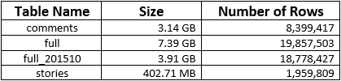

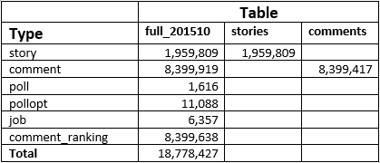

**Note: There is a discrepancy of 502 records between the number of records in the comments table and the number of record in the full_201510 table that is labelled “comment”**

Therefore, the **stories** and **comments** tables are subsets of the **full_210510** table. We can remove them from the analysis and focus only on the table labelled, **full**.

### The full table schema

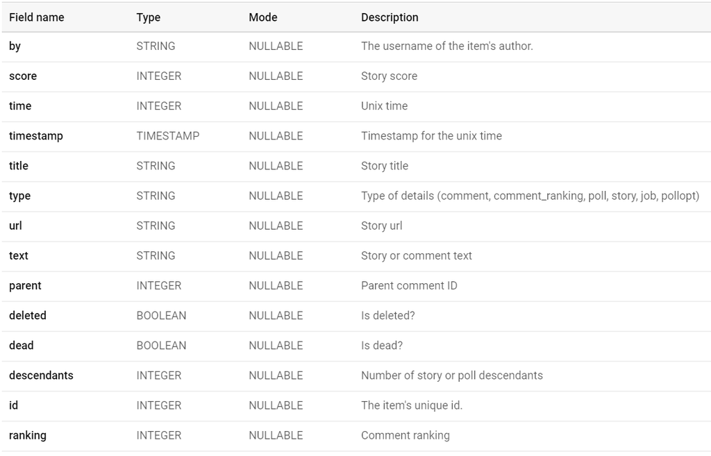

- The **full** table:
  - First entry - 2006-10-09 18:21:51 UTC
  - Last entry - current
  - 26821 missing timestamp entries (total empty entries)

#### The type field

The records are differentiated by the type field.

- The type field is a nominal categorical variable which have types:
  - comment - (16,548,891 entries)
  - story - (3,301,680 entries)
  - job - (11,924 entries)
  - pollopt - (12,019 entries)
  - poll - (1,760 entries)

*Note: There is no type “comment_ranking” in the full table.*

Poll : These are online polls that are run regarding various topics.  
Pollopt : These are different options available for the polls (Yes/No; Male/Female; Paper/Digital)  
story : These are stories posted by users  
comments : These are comment by users on stories  
job : These are online job ads

#### Bad field naming

- “by” is a sql key word. In order to use it you have to alias the table and then reference it through the alias. Otherwise, SQL reports an error.
- Rename “by” to “author” or " username"

#### The time and timestamp fields

- The time field (INT) - seconds since the great epoch - 1970
- The timestamp field (TIMESTAMP) can keep track of time zones

#### The parent field

- This field references the id to its parent record (another comment - linked list/graph)

#### The descendants field

- Hold the number of descendant (comments?) for the story and polls

#### The ranking field

- This field has only NULL values

#### Field descriptions

- The “type” field lists the wrong types in its description
- Rename “type” description to “Type of entry”
- “by” - “The username of the item’s author”. Rename to “The username”
- “timestamp” - Rename to “Entry submitted timestamp”
- “text” - rather rename to “comment”
- Rename descendant desctiprion to “Number of comments”
- “id” - Add the words “auto increment”

#### Summary

- 6 x Integer fields
- 2 x Boolean
- 5 x String fields (1 is probably a BLOB)
- 1 x Timestamp

## Task 2: Identify any characteristics of the data that could make it either easy or challenging for ANZ to use the data.

- Data Issues - Forum context (data contains insights: behavioural, media, sentiment)
  - Stories are posted mostly as url links. This makes collecting the story matter more difficult (web crawling/scraping)
  - Text mining - rely on the title fields to get a sense of what the story is about
  - The value of the forum data lies mostly in the comments
  - Comments are captured in a blob and makes it difficult to cross-correlate with other data sources
  - Forum content is too wide and open
- Optimization recommendations
  - The time field is redundant - remove
    - (INT) - 64 bits: (19,890,873 x 8 bytes) / 1024 bytes = *155 MB*
  - The ranking field is redundant - remove
    - (INT) - 64 bits: (19,890,873 x 8 bytes) / 1024 bytes = *155 MB*
  - All fields are NULLABLE - causes 26821 empty entries)
    - (7.4 GB / 19,890,873 rows) = (372 bytes/row * 26821 empty rows) / 1024 bytes = *9.7 MB*
  - All data is stored in one table - split up into relational tables and normalize.
    - Gets rid of “type” field: BigQuery suggest saving *164.4 MB*
  - Rename the field **by** to something sensible - e.g.UserName
  - There are plenty of duplicate values in the poll options (e.g. yes/no)
- Inconsistencies between tables
  - Several inconsistencies between all four the tables
  - time, timestamp, time_ts
  - by, author
  - mismatching type categories
- Recommendations
  - Design new HN DB
  - Pros:
    - Relational layout - easier to understand
    - Might have improved performance
    - Save disk space - enforce constraints
  - Cons:
    - Will it really improve performance? (@ +- 2 submits/second)
    - Multiple joins needed

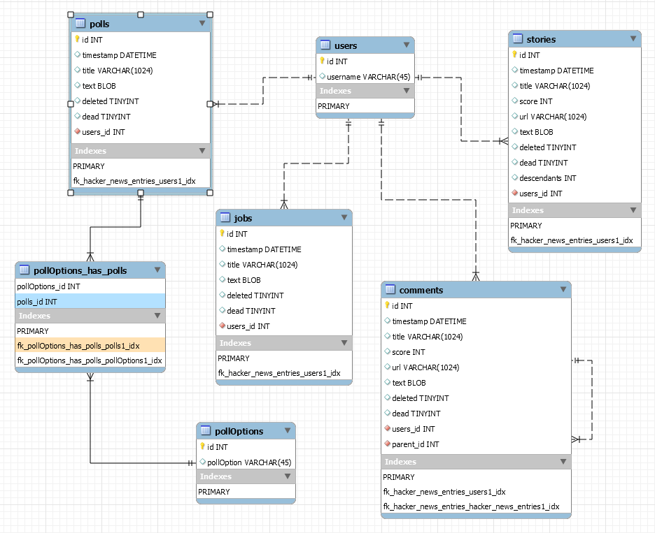

### DIKW - Data /Information / Knowledge / Wisdom

- Hierarchy
  - Helps to contextualize information flow
  - Information symmetry/asymmetry
  - Shapes analytics narrative

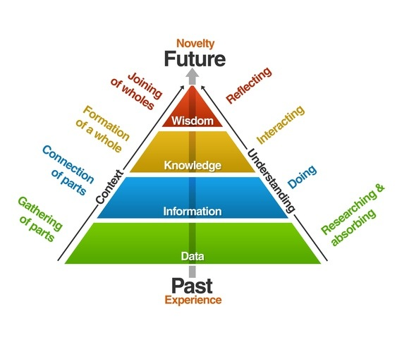

## Task 3: Identify some interesting findings in the data

- Technique used
  - NLP - Natural Language Processing
  - Text Mining
  - Create word cloud of most frequent words used around a central topic/word

```r
# Load
library("tm")
library("SnowballC")
library("wordcloud")
library("RColorBrewer")

create_word_map <- function(path_and_filename, max_words){

  #Create Corpus
  text <- readLines(path_and_filename)

  docs <- Corpus(VectorSource(text))

  #inspect(docs)

  toSpace <- content_transformer(function (x , pattern ) gsub(pattern, " ", x))
  docs <- tm_map(docs, toSpace, "/")
  docs <- tm_map(docs, toSpace, "@")
  docs <- tm_map(docs, toSpace, "\\|")

  # Convert the text to lower case
  docs <- tm_map(docs, content_transformer(tolower))
  # Remove numbers
  docs <- tm_map(docs, removeNumbers)
  # Remove english common stopwords
  docs <- tm_map(docs, removeWords, stopwords("english"))
  # specify your stopwords as a character vector
  docs <- tm_map(docs, removeWords, c("donxt",
                                      "isnxt",
                                      "just",
                                      "can",
                                      "will",
                                      "think",
                                      "one"))
  # Remove punctuations
  docs <- tm_map(docs, removePunctuation)
  # Eliminate extra white spaces
  docs <- tm_map(docs, stripWhitespace)
  # Text stemming
  # docs <- tm_map(docs, stemDocument)

  dtm <- TermDocumentMatrix(docs)
  m <- as.matrix(dtm)
  v <- sort(rowSums(m),decreasing=TRUE)
  d <- data.frame(word = names(v),freq=v)
  #head(d, 10)

  set.seed(1489)
  wordcloud(words       = d$word,
            freq        = d$freq,
            min.freq    = 1,
            max.words   = max_words,
            random.order= FALSE,
            rot.per     = 0.35,
            colors=brewer.pal(8, "Dark2"))
}
```

### Word cloud: VW (Titles)

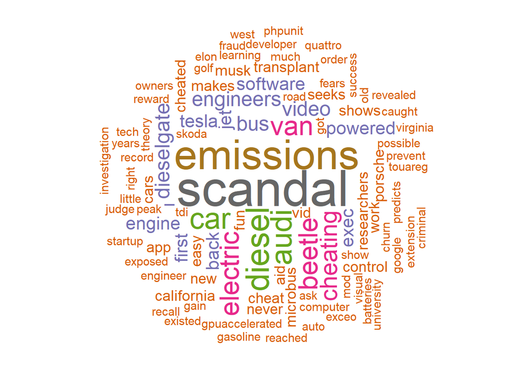

### Word cloud: VW (Comments)

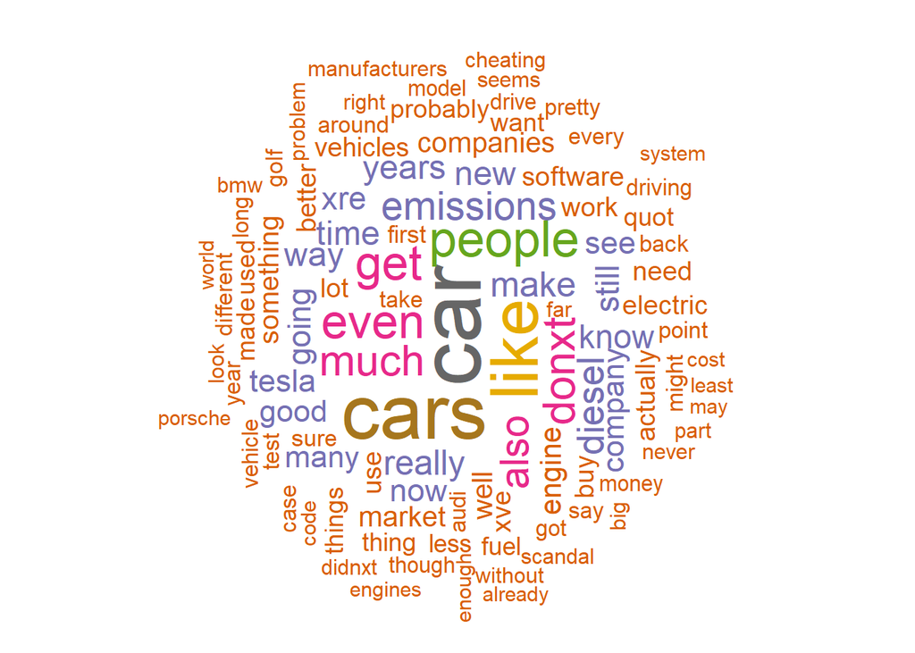

### Word cloud: Trump (Titles)

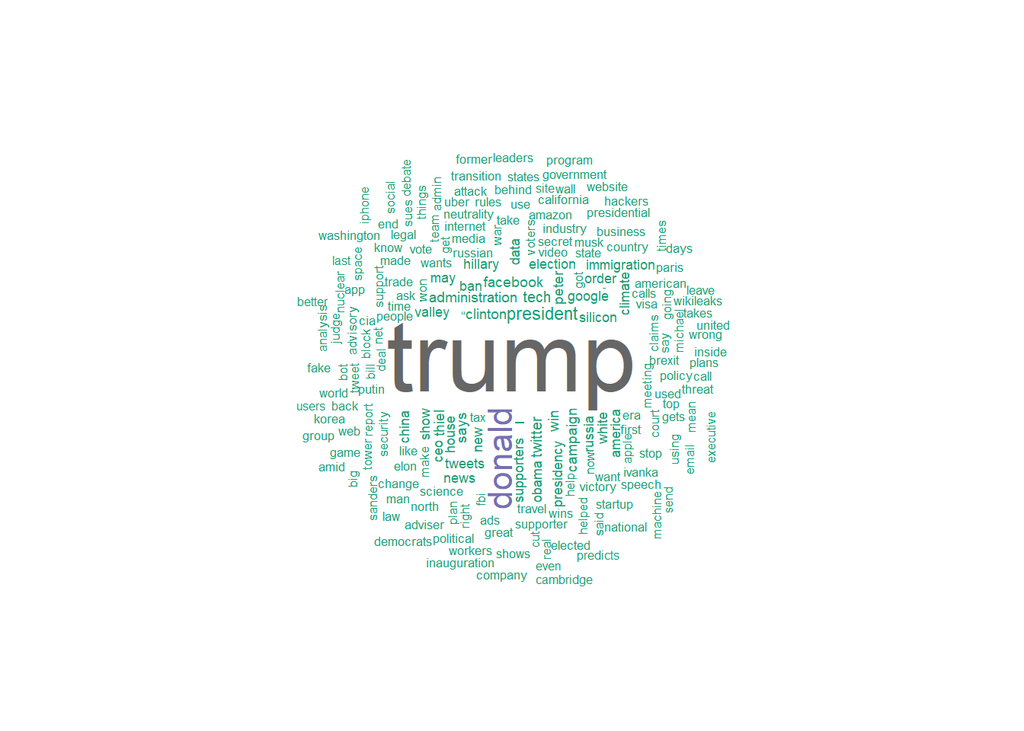

### Word cloud: Obama (Titles)

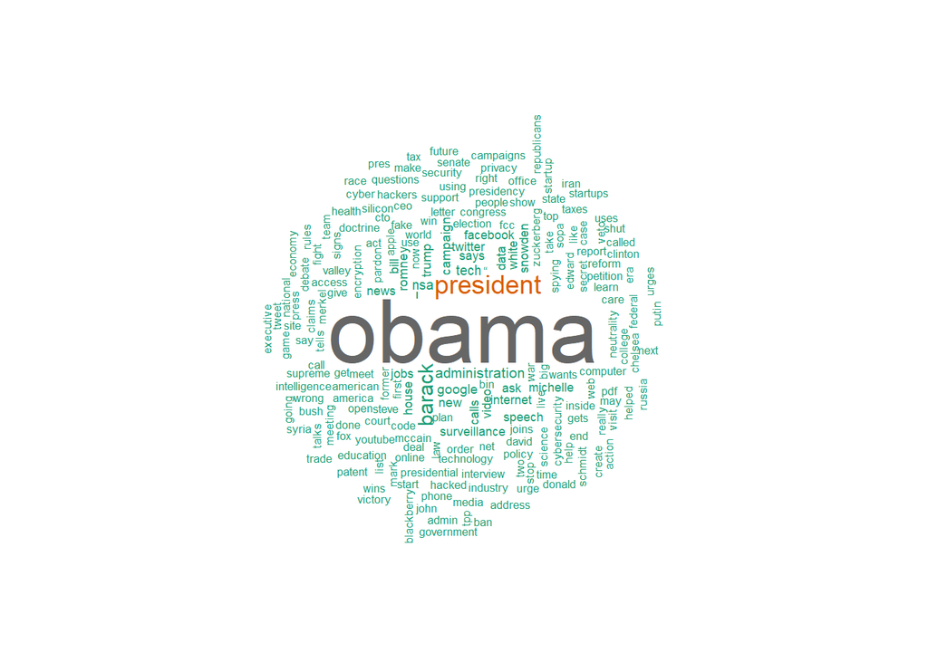